# Reproducible Research Project 2

Tracy Wormwood

2024-06-10

# Analysis of health and monetary impacts of weather events in USA from 1950-2011.

## Synopsis

The data analyzed in this report was extracted from the U.S. National Oceanic and Atmospheric Administration’s (NOAA) storm database. The data collected details fatalities and injuries to humans, as well as crop and property damage for more than 900,000 weather events over a time period of 60 years in the United States. In order to determine which weather phenomena have been most harmful to human health, the total injuries and fatalities for each weather event type were calculated, and the event types with the highest sums are reported. To determine which weather phenomena were most costly, the total costs of crop and property damages were calculated and the event types with the highest sums are reported here.

## Data Processing

### Download and impact on health

Data can be downloaded from a bzip file. The csv is extracted upon download automatically.

```r
fileUrl<-"https://d396qusza40orc.cloudfront.net/repdata%2Fdata%2FStormData.csv.bz2"
download.file(fileUrl, destfile="/Users/Tracy/Desktop/RR Project 2/data.csv")
```

Next, the data is read into R. To investigate the weather events that are most harmful to human health (Question 1), the dataset will be cropped to only include the variables event type, fatalities and injuries.

```r
data<-read.csv("./data.csv")
library(dplyr)
health<-select(data, EVTYPE, FATALITIES, INJURIES)
event_cat<-unique(health$EVTYPE)
table_event<-table(health$EVTYPE)
table_event<-as.data.frame(table_event)
```

Next, the sum of fatalities and injuries for each event type are calculated using tapply:

```r
sum_fatal<-tapply(health$FATALITIES, health$EVTYPE, sum)
sum_fatal<-as.data.frame(sum_fatal)
sum_fatal$evtype<-table_event$Var1


sum_injury<-tapply(health$INJURIES, health$EVTYPE, sum)
sum_injury<-as.data.frame(sum_injury)
sum_injury$evtype<-table_event$Var1
```

After those sums are calculated, the top ten event causes for both injuries and fatalities are reported, and then intersect() can be used to find which event types are in common between the two datasets (injury and fatality).

```r
sum_fatal_num<-filter(sum_fatal, sum_fatal>0)
sum_injury_num<-filter(sum_injury, sum_injury>0)

order_fatal<-sum_fatal[with(sum_fatal, order(-sum_fatal)),]
top_10_fatal<-order_fatal[1:10,]

order_inj<-sum_injury[with(sum_injury, order(-sum_injury)),]
top_10_injury<-order_inj[1:10,]

common<-intersect(top_10_fatal$evtype, top_10_injury$evtype)
common
```

```
## [1] "TORNADO"        "EXCESSIVE HEAT" "FLASH FLOOD"    "HEAT"
## [5] "LIGHTNING"      "TSTM WIND"      "FLOOD"
```

### Processing for economic impact

In order to process data to answer question 2, only the required variables are kept in the dataset. These are event type, property damage, property damage exponent, crop damage, and crop damage exponent. The values listed for property damage exponent appear to be confusing so this will be investigated here.

```r
damage<-select(data, EVTYPE, PROPDMG, PROPDMGEXP, CROPDMG, CROPDMGEXP)

table(damage$PROPDMGEXP)
```

```
##
##             -      ?      +      0      1      2      3      4      5      6
## 465934      1      8      5    216     25     13      4      4     28      4
##      7      8      B      h      H      K      m      M
##      5      1     40      1      6 424665      7  11330
```

```r
filter(damage, PROPDMGEXP=="?")
```

```
##               EVTYPE PROPDMG PROPDMGEXP CROPDMG CROPDMGEXP
## 1 THUNDERSTORM WINDS       0          ?       0
## 2        FLASH FLOOD       0          ?       0
## 3        FLASH FLOOD       0          ?       0
## 4  THUNDERSTORM WIND       0          ?       0
## 5               HAIL       0          ?       0
## 6               HAIL       0          ?       0
## 7               HAIL       0          ?       0
## 8 THUNDERSTORM WINDS       0          ?       0
```

All of these rows have “0” value for property damage. These can be filtered out. Additionally, do those labeled with “+” for the property damage exponent have a value?

```r
filter(damage, PROPDMGEXP=="+")
```

```
##                EVTYPE PROPDMG PROPDMGEXP CROPDMG CROPDMGEXP
## 1    BREAKUP FLOODING      20          +       0
## 2           HIGH WIND      20          +       0
## 3 FLOODING/HEAVY RAIN       2          +       0
## 4          HIGH WINDS      15          +       0
## 5             TORNADO      60          +       0
```

Here, the five rows with a “+” do have a numeric value. I’m going to read the notes from a few of these cases, but first an index must be added to the damage data frame so the case can be easily looked up from the data data frame.

```r
damage$index<-seq.int(nrow(damage))
plus<-filter(damage, PROPDMGEXP=="+")
```

The case notes from index=188780:

```r
data[188780,]
```

```
##        STATE__         BGN_DATE BGN_TIME TIME_ZONE COUNTY COUNTYNAME STATE
## 188780       2 5/1/1995 0:00:00     0000       AST      0     AKZ001    AK
##                  EVTYPE BGN_RANGE BGN_AZI       BGN_LOCATI          END_DATE
## 188780 BREAKUP FLOODING         0         Southwest Alaska 5/31/1995 0:00:00
##        END_TIME COUNTY_END COUNTYENDN END_RANGE END_AZI END_LOCATI LENGTH WIDTH
## 188780                   0         NA         0                         0     0
##         F MAG FATALITIES INJURIES PROPDMG PROPDMGEXP CROPDMG CROPDMGEXP WFO
## 188780 NA   0          0        0      20          +       0
##        STATEOFFIC         ZONENAMES LATITUDE LONGITUDE LATITUDE_E LONGITUDE_
## 188780            HOUSTON - HOUSTON        0         0          0          0
##                                                                                                                                                                                                                                                                                                          …
## 188780 Typical of this time of year is the seasonal breakup process across mainland Alaska.  Major rivers, which serve as transportation corridors around the state, undergo the change from ice covered roadways (even plowed by the state) to summer boat/barge traffic.  May 6th and 7th brought flood…
##        REFNUM
## 188780 188780
```

The property damage value is 20, and the exponent is “+”. From reading the notes it’s not clear how the number 20 was determined. To make this analysis simpler, the damage data frame will be filtered to only include cases which have a K, M, or B for the property damage exponent value. The same will also be applied for crop damage exponent values. Then, lowercase values will be converted to uppercase values.

```r
list<-c("K", "k", "M", "m", "B")
damage_filter<-filter(damage, PROPDMGEXP %in% list | CROPDMGEXP %in% list)
damage_filter$PROPDMGEXP2<-toupper(damage_filter$PROPDMGEXP)
damage_filter$CROPDMGEXP2<-toupper(damage_filter$CROPDMGEXP)
```

The uppercase values were created in a new column. The old column will be removed and the “new” column will be renamed. Additionally, there appear to be some cases where there is a “K” value, but the number for damage is 0. These need to be removed as well (damage_filter_both).

```r
damage_filter<-select(damage_filter, EVTYPE, PROPDMG, PROPDMGEXP2, CROPDMG, CROPDMGEXP2, index)
damage_filter<-rename(damage_filter, PROPDMGEXP=PROPDMGEXP2, CROPDMGEXP=CROPDMGEXP2)
damage_filter_both<-filter(damage_filter, PROPDMG>0 | CROPDMG>0)
```

Now the damage values should be calculated in numeric form. The property or crop damage value should be multiplied by the “K”, “M” or “B” value and should be stored in a new column. This can be performed by writing two functions, multiplier_prop and multiplier_crop:

```r
multiplier_prop<-function(dataset) {
    newdataset<-data.frame()

    for (i in 1:nrow(dataset))
        if (dataset$PROPDMGEXP[[i]]=="K") {
            newdataset<-rbind(newdataset, value=dataset$PROPDMG[[i]]*1000)}

            else if (dataset$PROPDMGEXP[[i]]=="M") {
                newdataset<-rbind(newdataset, value=dataset$PROPDMG[[i]]*1000000)}

                else if (dataset$PROPDMGEXP[[i]]=="B") {
                    newdataset<-rbind(newdataset, value=dataset$PROPDMG[[i]]*1000000000)}

                    else newdataset<-rbind(newdataset, value=0)

    newdataset
}



multiplier_crop<-function(dataset) {
    newdataset<-data.frame()

    for (i in 1:nrow(dataset))
        if (dataset$CROPDMGEXP[[i]]=="K") {
            newdataset<-rbind(newdataset, value=dataset$CROPDMG[[i]]*1000)}

    else if (dataset$PROPDMGEXP[[i]]=="M") {
        newdataset<-rbind(newdataset, value=dataset$CROPDMG[[i]]*1000000)}

    else if (dataset$PROPDMGEXP[[i]]=="B") {
        newdataset<-rbind(newdataset, value=dataset$CROPDMG[[i]]*1000000000)}

    else newdataset<-rbind(newdataset, value=0)

    newdataset
}
```

Then, the output of these two functions was added to the damage_filter_both dataset. These are numeric values for property and crop damage.

```r
damage_filter_both$propertydamage<-multiplier_prop(damage_filter_both)
damage_filter_both$cropdamage<-multiplier_crop(damage_filter_both)
```

After these values are calculated, tapply can be run to find the sum of property/crop damages by event type. The two resulting data frames are summed in the dataset (both) to determine the total economic impact.

```r
prop_sum<-tapply(damage_filter_both$propertydamage, damage_filter_both$EVTYPE, sum)
prop_sum<-as.data.frame(prop_sum)

crop_sum<-tapply(damage_filter_both$cropdamage, damage_filter_both$EVTYPE, sum)
crop_sum<-as.data.frame(crop_sum)

both<-cbind(crop_sum, prop_sum)
both$eventtype<-rownames(both)
both$total<-(crop_sum+prop_sum)
```

As with human health, it would be interesting to find the top 10 event types regarding economic impact for both crop and property damage. It would also be interesting to know the sum of crop and property damages for event types and see which events are most costly.

```r
order_prop<-both[with(both, order(-prop_sum)),]
top_10_prop<-order_prop[1:10,]

order_crop<-both[with(both, order(-crop_sum)),]
top_10_crop<-order_crop[1:10,]

common_value<-intersect(top_10_crop$eventtype, top_10_prop$eventtype)
common_value
```

```
## [1] "HURRICANE"         "HURRICANE/TYPHOON" "FLOOD"
## [4] "HAIL"              "FLASH FLOOD"
```

Earlier the sum of crop and property damage (both$total) was calculated. Now these values can be ordered and the top ten can be reported. The sum calculated earlier is recorded as a dataframe so it must be transformed that to an object that can be ordered.

```r
str(both)
```

```
## 'data.frame':    426 obs. of  4 variables:
##  $ crop_sum : num  0 0 0 0 0 0 0 0 0 0 ...
##  $ prop_sum : num  200000 50000 8100000 8000 5000 ...
##  $ eventtype: chr  "   HIGH SURF ADVISORY" " FLASH FLOOD" " TSTM WIND" " TSTM WIND (G45)" ...
##  $ total    :'data.frame':   426 obs. of  1 variable:
##   ..$ crop_sum: num  200000 50000 8100000 8000 5000 ...
```

```r
total_value<-select(both, 3:4)
str(total_value)
```

```
## 'data.frame':    426 obs. of  2 variables:
##  $ eventtype: chr  "   HIGH SURF ADVISORY" " FLASH FLOOD" " TSTM WIND" " TSTM WIND (G45)" ...
##  $ total    :'data.frame':   426 obs. of  1 variable:
##   ..$ crop_sum: num  200000 50000 8100000 8000 5000 ...
```

```r
total_value_2<-unlist(total_value$total)
str(total_value_2)
```

```
##  Named num [1:426] 200000 50000 8100000 8000 5000 ...
##  - attr(*, "names")= chr [1:426] "crop_sum1" "crop_sum2" "crop_sum3" "crop_sum4" ...
```

```r
both$totalval<-cbind(total_value_2)
order_total<-both[with(both, order(-totalval)),]
top_10_total<-order_total[1:10,]

top_10_total
```

```
##                               crop_sum     prop_sum                 eventtype
## HURRICANE                 802881910000  11868319010                 HURRICANE
## HURRICANE/TYPHOON         430370342800  69305840000         HURRICANE/TYPHOON
## FLOOD                      35149748450 144657709800                     FLOOD
## TORNADO                      194933110  56937160480                   TORNADO
## STORM SURGE                       5000  43323536000               STORM SURGE
## FLASH FLOOD                 1058517100  16140811510               FLASH FLOOD
## HAIL                        1127274450  15732266720                      HAIL
## WILDFIRE                    6593472800   4765114000                  WILDFIRE
## RIVER FLOOD                 5022459000   5118945500               RIVER FLOOD
## HURRICANE OPAL/HIGH WINDS  10000000000    100000000 HURRICANE OPAL/HIGH WINDS
##                               crop_sum total_value_2
## HURRICANE                 814750229010  814750229010
## HURRICANE/TYPHOON         499676182800  499676182800
## FLOOD                     179807458250  179807458250
## TORNADO                    57132093590   57132093590
## STORM SURGE                43323541000   43323541000
## FLASH FLOOD                17199328610   17199328610
## HAIL                       16859541170   16859541170
## WILDFIRE                   11358586800   11358586800
## RIVER FLOOD                10141404500   10141404500
## HURRICANE OPAL/HIGH WINDS  10100000000   10100000000
```

```r
common_total<-intersect(top_10_total$eventtype, common_value)
common_total
```

```
## [1] "HURRICANE"         "HURRICANE/TYPHOON" "FLOOD"
## [4] "FLASH FLOOD"       "HAIL"
```

## Results

### Across the United States, which types of events (as indicated in the EVTYPE variable) are most harmful with respect to population health?

The weather events that are most damaging to human health, considering fatalities and injuries, are TORNADO, EXCESSIVE HEAT, FLASH FLOOD, HEAT, LIGHTNING, TSTM WIND, FLOOD.

The package ggplot2 is used to create a bar graph showing the event types with the most fatalities and injuries.

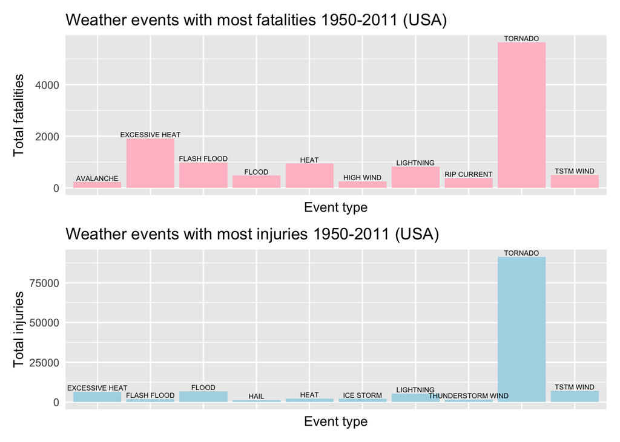

```r
library(ggplot2)

f<-ggplot(top_10_fatal, aes(x=evtype, y=sum_fatal))+geom_col(fill="pink")+geom_text(aes(label=evtype), size=2, vjust=-0.3)+ylab("Total fatalities")+xlab("Event type")+ggtitle("Weather events with most fatalities 1950-2011 (USA)")+theme(axis.text.x=element_blank(), axis.ticks = element_blank(), legend.position = "none")

i<-ggplot(top_10_injury, aes(x=evtype, y=sum_injury))+geom_col(fill="lightblue")+geom_text(aes(label=evtype), size=2, vjust=-0.3)+ylab("Total injuries")+xlab("Event type")+ggtitle("Weather events with most injuries 1950-2011 (USA)")+theme(axis.text.x=element_blank(), axis.ticks = element_blank(), legend.position = "none")

library(patchwork)
f/i
```

```r
png(filename = "Healthimpact.png", width=480, height=960)
f/i
dev.off()
```

The graph shows that tornadoes are by far the most harmful to human health.

### Across the United States, which types of events have the greatest economic consequences?

There are five event types in common for the most costly damages. These five are HURRICANE, HURRICANE/TYPHOON, FLOOD, HAIL, FLASH FLOOD.

Finally, a plot will be created to summarize the investigation of question 2.

```r
library(data.table)
```

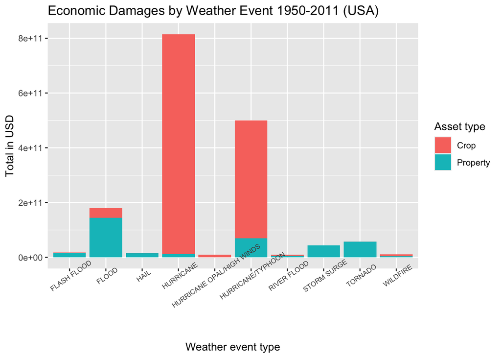

```r
top_10_t<-as.data.table(top_10_total)
top_10_damage<-melt(top_10_t, id.vars=3, measure.vars=c(1,2))
dam<-ggplot(top_10_damage, aes(x=eventtype, y=value, fill=variable))+geom_col()+theme(axis.text.x = element_text(size=7, angle=35))+labs(x="Weather event type", y="Total in USD", title="Economic Damages by Weather Event 1950-2011 (USA)")+scale_fill_discrete(name="Asset type", labels = c("Crop", "Property"))

dam
```

```r
png(filename="Economicimpact.png", width=900, height=600)
dam
dev.off()
```

The crop damage incurred by hurricanes and typhoons is notably higher than the other weather event types. Floods have are costliest in terms of property damage.

### Conclusion

In summary, from 1950-2011 in the United States tornadoes were most harmful to human health, and hurricanes had the greatest economic consequences.